# Lesson 2: Working with data frames

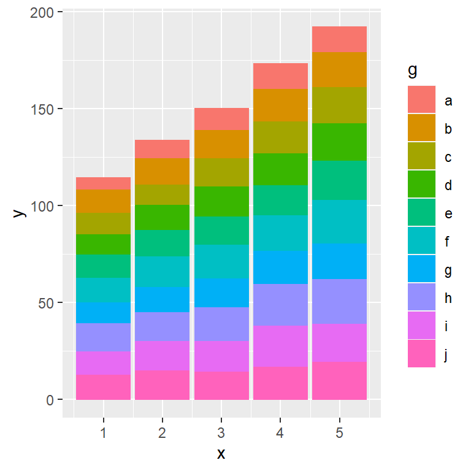

```r
ggplot(dat, aes(x = x, y = y, color = g, fill = g)) +
  geom_col()
```

Additional arguments can be added to change the appearance of the plot, alter the geoms, or add other graphical elements that are not mapped from the data frame. For instance we can change our stacked bar plot to a grouped bar plot by an argument to `geom_col()`. Then we can change the theme by adding `theme_bw()`, and also add a horizontal dotted line on the plot by adding another geom.

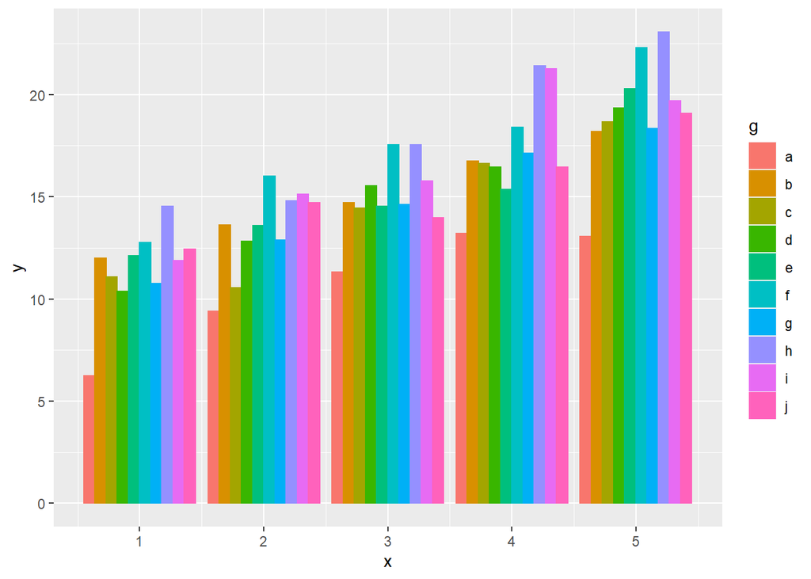

```r
barplot <- ggplot(dat, aes(x = x, y = y, color = g, fill = g)) +
  geom_col(position = 'dodge')

barplot
```

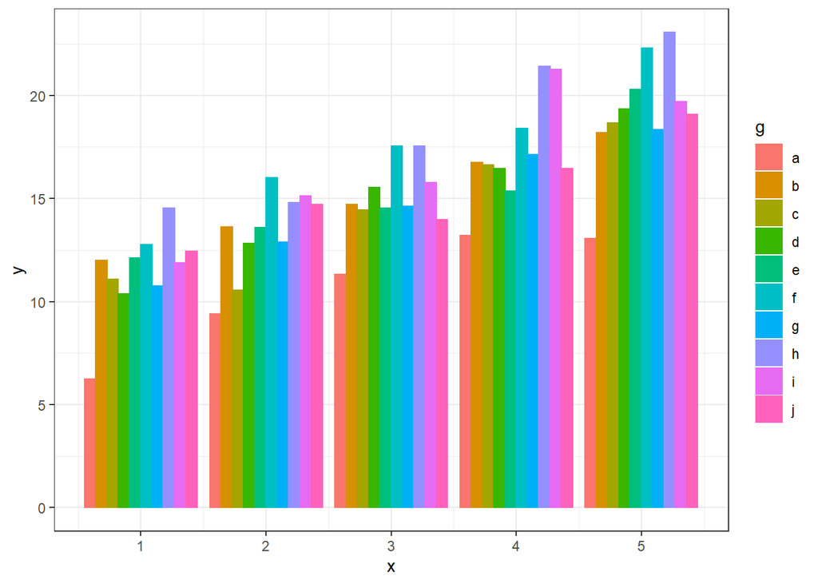

```r
barplot + theme_bw()
```

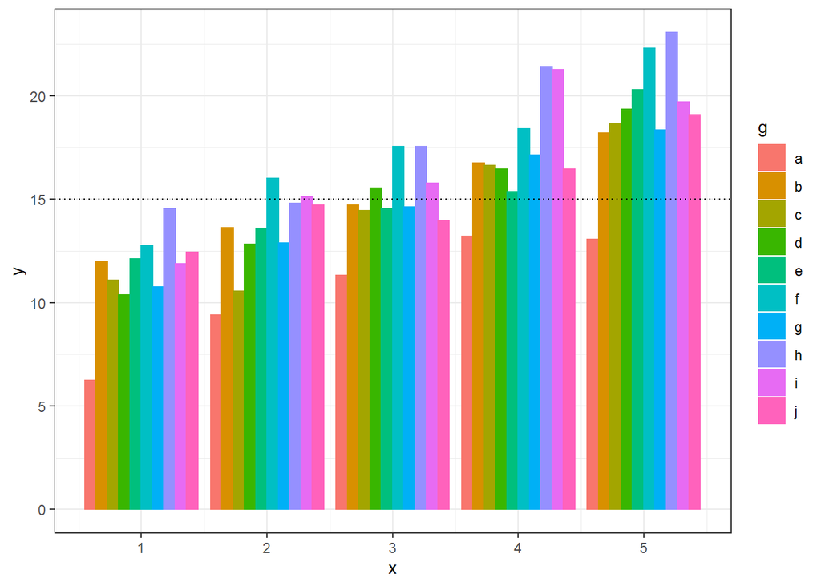

```r
barplot + theme_bw() + geom_hline(yintercept = 15, linetype = 'dotted')
```

# Fit a model

```r
fit <- lmer(y ~ x + (1|g), data = dat)
```

```r
fixef(fit)
```

```
## (Intercept)           x
##    9.398182    1.952192
```

```r
ranef(fit)
```

```
## $g
##   (Intercept)
## a -4.39034052
## b -0.20023429
## c -0.93192649
## d -0.33121119
## e -0.06748659
## f  2.04254561
## g -0.48573298
## h  2.86827218
## i  1.42067609
## j  0.07543819
##
## with conditional variances for "g"
```

```r
anova(fit)
```

```
## Type III Analysis of Variance Table with Satterthwaite's method
##   Sum Sq Mean Sq NumDF DenDF F value    Pr(>F)
## x 381.11  381.11     1    39  374.06 < 2.2e-16 ***
## ---
## Signif. codes:  0 '***' 0.001 '**' 0.01 '*' 0.05 '.' 0.1 ' ' 1
```

# Exercises